# Assignment_4

Anaushka Goyal

2025-04-12

## Loading Packages

```r
library(tidyverse)
library(caret)
library(pROC)
```

## Given Code

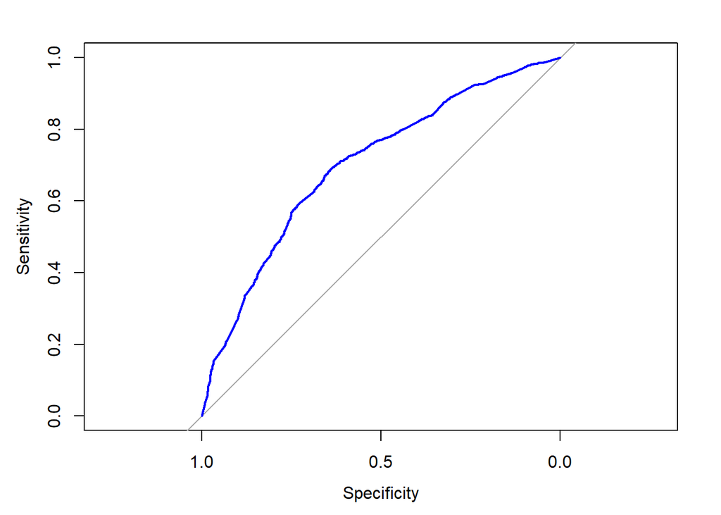

```r
# STEP 1: Load the dataset (call it recidivism_ga)
recidivism_ga<- read_csv("C:/Users/goyal/Desktop/Spring_2025/PPA_Spring_2025/Week_4_4_2025/NIJ_s_Recidivism_Challenge_Full_Dataset_20240407.csv")
# STEP 2: Explore the data
glimpse(recidivism_ga)
summary(recidivism_ga)

# STEP 3: Create binary outcome variable
recidivism_ga <- recidivism_ga %>%
  mutate(recidivism_yes = if_else(Recidivism_Within_3years == TRUE, 1, 0))

recidivism_ga <- na.omit(recidivism_ga) #ommitting na values to make model correct
# STEP 4: Partition the data into training and testing sets
set.seed(1234)
trainIndex <- createDataPartition(recidivism_ga$recidivism_yes, p = 0.7, list = FALSE)
train <- recidivism_ga[trainIndex, ]
test <- recidivism_ga[-trainIndex, ]

# STEP 5: Fit logistic regression model
model <- glm(recidivism_yes ~ Age_at_Release + Gang_Affiliated + Percent_Days_Employed,
             data = train, family = "binomial")
summary(model)

#if u take an exponenet of a coefficient, it tells you more likely what u are likely to commit a crime.  Example expo (xyz) of a age coefficient tells you they are zyxb higher on committing crime.
## the cutoof wvalue creates that balance between speicificty and specificity

# STEP 6: Predict probabilities on test set
test_probs <- predict(model, newdata = test, type = "response")
threshold <- 0.60
test_preds <- ifelse(test_probs > threshold, 1, 0)

# STEP 7: Evaluate overall model performance
confusionMatrix(as.factor(test_preds), as.factor(test$recidivism_yes), positive = "1")
roc_obj <- roc(test$recidivism_yes, test_probs)
plot(roc_obj, col = "blue")
```

```r
auc(roc_obj)

# STEP 8: Explore group-wise performance by race
group_metric_summary <- test %>%
  mutate(pred = test_preds, prob = test_probs) %>%
  group_by(Race) %>%
  summarise(
    Sensitivity = sum(pred == 1 & recidivism_yes == 1) / sum(recidivism_yes == 1),
    Specificity = sum(pred == 0 & recidivism_yes == 0) / sum(recidivism_yes == 0),
    Precision = sum(pred == 1 & recidivism_yes == 1) / sum(pred == 1),
    N = n()
  )

print(group_metric_summary)
```

## Task 1

Sensitivity is about catching true positives, that means people who were predicted to recidivate based on their background and actually did within three years of parole. Specificity tells us the true negatives, those who were predicted not to recidivate and didn’t. I think it’s really important to get sensitivity right, because we need a better understanding of who is at risk of reoffending so that we can provide them with the right preventive measures and support to help them reintegrate into society.

At the same time, having too many false positives (low specificity) can be harmful in the context of parole, if someone has a low chance of reoffending but the model predicts they will, they could face unnecessary restrictions. In cases of more serious crimes like murder or violent offenses, I think sensitivity should be prioritized over specificity because it’s more important to identify those who truly might commit another crime, even if it means a few false positives.

## Task 2 - Exploratory Data Analysis + Model Building

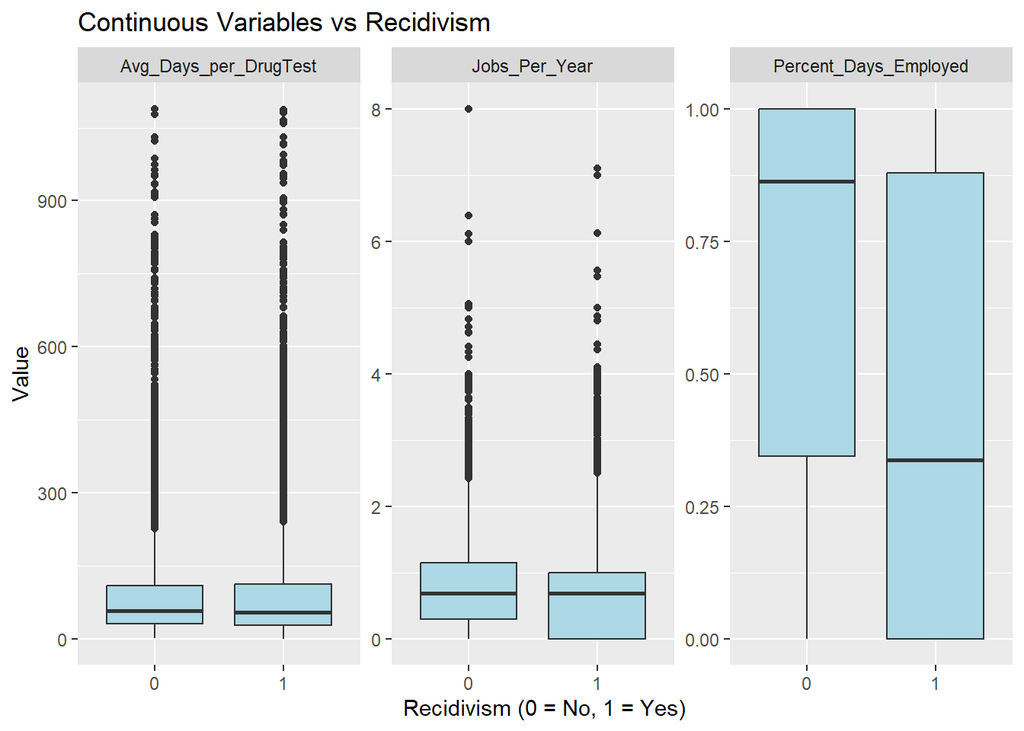

```r
## used chatgpt help as I did not know the correct syntax for these plots.

# Continuous variables
recidivism_ga %>%
  pivot_longer(cols = c(Percent_Days_Employed, Jobs_Per_Year, Avg_Days_per_DrugTest),
               names_to = "variable", values_to = "value") %>%
  ggplot(aes(x = factor(recidivism_yes), y = value)) +
  geom_boxplot(fill = "lightblue") +
  facet_wrap(~ variable, scales = "free_y") +
  labs(x = "Recidivism (0 = No, 1 = Yes)", y = "Value", title = "Continuous Variables vs Recidivism")
```

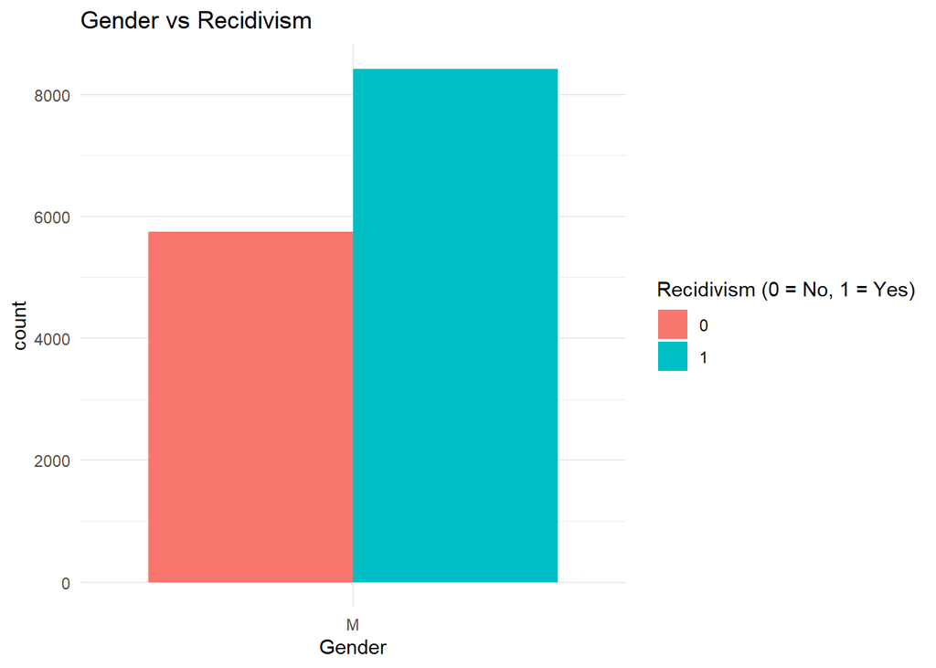

```r
##Categorical Variables
# Plot 1: Gender vs Recidivism
ggplot(recidivism_ga, aes(x = Gender, fill = factor(recidivism_yes))) +
  geom_bar(position = "dodge") +
  labs(title = "Gender vs Recidivism", fill = "Recidivism (0 = No, 1 = Yes)") +
  theme_minimal()
```

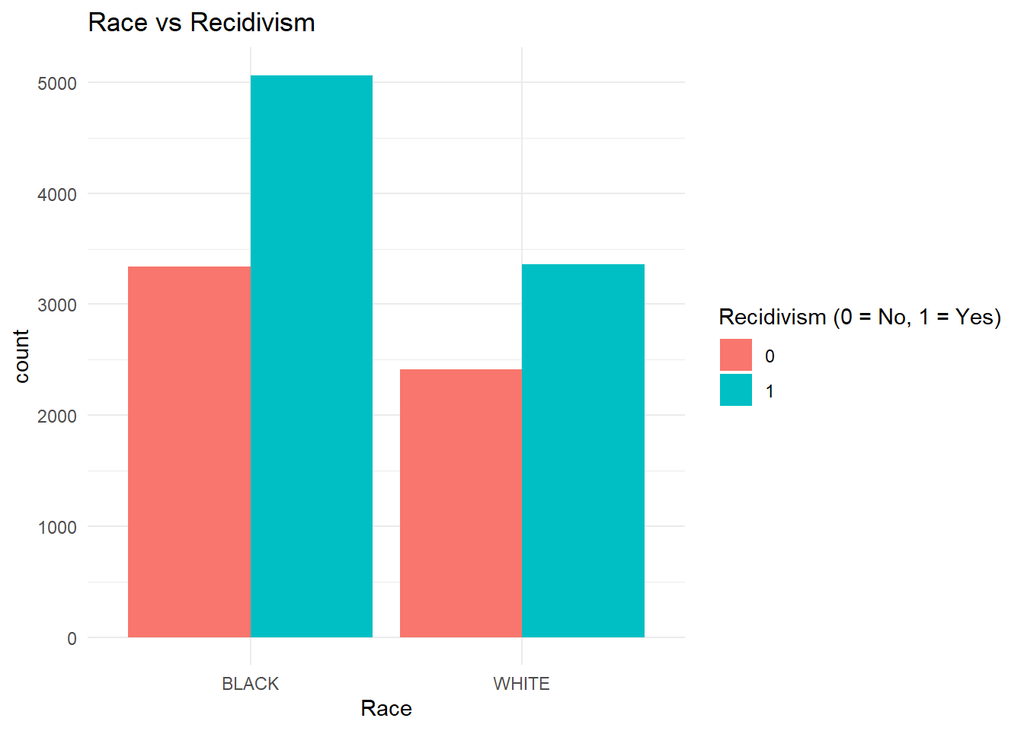

```r
# Plot 2: Race vs Recidivism
ggplot(recidivism_ga, aes(x = Race, fill = factor(recidivism_yes))) +
  geom_bar(position = "dodge") +
  labs(title = "Race vs Recidivism", fill = "Recidivism (0 = No, 1 = Yes)") +
  theme_minimal()
```

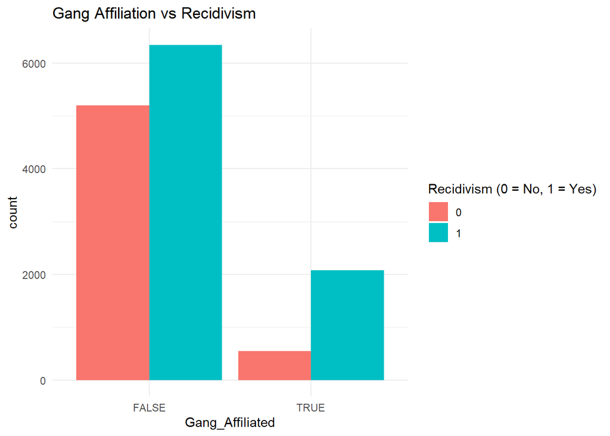

```r
# Plot 3: Gang Affiliation vs Recidivism
ggplot(recidivism_ga, aes(x = Gang_Affiliated, fill = factor(recidivism_yes))) +
  geom_bar(position = "dodge") +
  labs(title = "Gang Affiliation vs Recidivism", fill = "Recidivism (0 = No, 1 = Yes)") +
  theme_minimal()
```

```r
set.seed(1234)
trainIndex <- createDataPartition(recidivism_ga$recidivism_yes, p = 0.7, list = FALSE)
train <- recidivism_ga[trainIndex, ]
test <- recidivism_ga[-trainIndex, ]


model1 <- glm(recidivism_yes ~ Percent_Days_Employed + Avg_Days_per_DrugTest +  Jobs_Per_Year + DrugTests_Cocaine_Positive + Education_Level, data = train, family = "binomial")
summary(model1)
```

```
##
## Call:
## glm(formula = recidivism_yes ~ Percent_Days_Employed + Avg_Days_per_DrugTest +
##     Jobs_Per_Year + DrugTests_Cocaine_Positive + Education_Level,
##     family = "binomial", data = train)
##
## Coefficients:
##                                       Estimate Std. Error z value Pr(>|z|)
## (Intercept)                          6.662e-01  6.741e-02   9.884  < 2e-16 ***
## Percent_Days_Employed               -2.167e+00  6.944e-02 -31.201  < 2e-16 ***
## Avg_Days_per_DrugTest               -7.749e-05  1.865e-04  -0.416  0.67777
## Jobs_Per_Year                        5.615e-01  3.573e-02  15.714  < 2e-16 ***
## DrugTests_Cocaine_Positive           1.194e+00  4.037e-01   2.959  0.00309 **
## Education_LevelHigh School Diploma   5.381e-01  6.376e-02   8.439  < 2e-16 ***
## Education_LevelLess than HS diploma  4.224e-01  6.482e-02   6.517 7.18e-11 ***
## ---
## Signif. codes:  0 '***' 0.001 '**' 0.01 '*' 0.05 '.' 0.1 ' ' 1
##
## (Dispersion parameter for binomial family taken to be 1)
##
##     Null deviance: 13431  on 9918  degrees of freedom
## Residual deviance: 12204  on 9912  degrees of freedom
## AIC: 12218
##
## Number of Fisher Scoring iterations: 4
```

```r
model2 <- glm(recidivism_yes ~ Age_at_Release + Jobs_Per_Year + Gang_Affiliated + Dependents + Prison_Offense , data = train, family = "binomial")
summary(model2)
```

```
##
## Call:
## glm(formula = recidivism_yes ~ Age_at_Release + Jobs_Per_Year +
##     Gang_Affiliated + Dependents + Prison_Offense, family = "binomial",
##     data = train)
##
## Coefficients:
##                                Estimate Std. Error z value Pr(>|z|)
## (Intercept)                    0.382066   0.093909   4.068 4.73e-05 ***
## Age_at_Release23-27            0.001666   0.087489   0.019 0.984811
## Age_at_Release28-32           -0.102890   0.089565  -1.149 0.250649
## Age_at_Release33-37           -0.155524   0.093186  -1.669 0.095122 .
## Age_at_Release38-42           -0.206424   0.099705  -2.070 0.038420 *
## Age_at_Release43-47           -0.412628   0.101999  -4.045 5.22e-05 ***
## Age_at_Release48 or older     -0.687602   0.096558  -7.121 1.07e-12 ***
## Jobs_Per_Year                 -0.115403   0.025476  -4.530 5.90e-06 ***
## Gang_AffiliatedTRUE            0.950279   0.064158  14.812  < 2e-16 ***
## Dependents1                    0.198035   0.060047   3.298 0.000974 ***
## Dependents2                    0.104394   0.064067   1.629 0.103220
## Dependents3 or more            0.004983   0.055239   0.090 0.928119
## Prison_OffenseOther            0.163773   0.074735   2.191 0.028424 *
## Prison_OffenseProperty         0.331500   0.058889   5.629 1.81e-08 ***
## Prison_OffenseViolent/Non-Sex -0.112924   0.061479  -1.837 0.066241 .
## Prison_OffenseViolent/Sex     -0.901181   0.108381  -8.315  < 2e-16 ***
## ---
## Signif. codes:  0 '***' 0.001 '**' 0.01 '*' 0.05 '.' 0.1 ' ' 1
##
## (Dispersion parameter for binomial family taken to be 1)
##
##     Null deviance: 13431  on 9918  degrees of freedom
## Residual deviance: 12721  on 9903  degrees of freedom
## AIC: 12753
##
## Number of Fisher Scoring iterations: 4
```

```r
##USING MODEL 1 AS THE FINAL MODEL
```